# Part3 Chapter 2-5

# 第2章 単回帰モデル

- [R script](https://github.com/logics-of-blue/book-r-stan-bayesian-model-intro/blob/master/book-data/3-2-%E5%8D%98%E5%9B%9E%E5%B8%B0%E3%83%A2%E3%83%87%E3%83%AB.R)

## 1.1 本章の目的と概要

- Stanを用いた単回帰モデルの推定方法を学ぶ
- RとStanを用いた一般化線形モデル推定の初歩を学ぶ

## 2.2 分析の準備

- パッケージの読み込みと，計算を高速化させるオプションを指定する（使い回しOK)

```r
# パッケージの読み込み
library(rstan)
library(bayesplot)
library(ggplot2)

# 計算の高速化
rstan_options(auto_write = TRUE)
options(mc.cores = parallel::detectCores())
```

## 2.3 データの読み込みと可視化

- [架空のビールの売り上げと気温のデータ](https://github.com/logics-of-blue/book-r-stan-bayesian-model-intro/blob/master/book-data/3-2-1-beer-sales-2.csv)を読み込む
- データを`ggplot2`で可視化する

```r
# 分析対象のデータ
file_beer_sales_2 <- read.csv("3-2-1-beer-sales-2.csv")
head(file_beer_sales_2, n = 3)
```

```
##    sales temperature
## 1  41.68        13.7
## 2 110.99        24.0
## 3  65.32        21.5
```

```r
# サンプルサイズ
sample_size <- nrow(file_beer_sales_2)
sample_size
```

```
## [1] 100
```

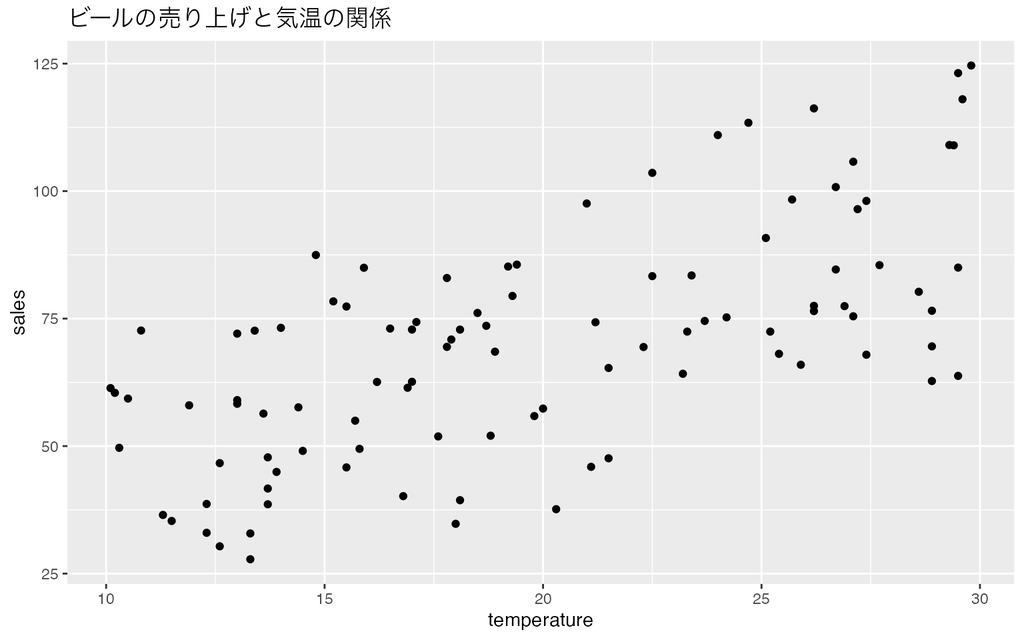

```r
# 図示
ggplot(file_beer_sales_2, aes(x = temperature, y = sales)) +
  geom_point() +
  labs(title = "ビールの売り上げと気温の関係")
```

## 2.4 モデルの構造

- 単回帰モデルは以下のような構造を取る
  - 正規分布に従う量的データが応答変数
  - 説明変数は量的データが1つ
  - リンク関数は恒等関数
  - 応答変数の平均値が説明変数によって変化することを想定

$$\mu_{i} = \beta_0+\beta_1x_{i}$$
$$y_{i} \sim Normal (\mu_{i},
\sigma^2)$$
- $\beta_0+\beta_1x_{i}$が線形予測子 - $\beta_0$が切片，$\beta_1x_{i}$が傾き
- 平均値$\mu_{i}$は説明変数（気温）が1変化すると$\beta_{1}$増加する

- 応答変数がビールの売り上げ，説明変数が気温の単回帰モデル
  - 「気温によって，ビールの売り上げの平均値が増減する」ことを想定したモデル
- $sales_i \sim Normal(Interceot + beta * temperature_i, sigma^2)$ (3.40)

## 2.5 単回帰モデルのためのStanファイルの実装

- [Stanファイルを式 (3.40)](https://github.com/logics-of-blue/book-r-stan-bayesian-model-intro/blob/master/book-data/3-2-1-simple-lm.stan) に合わせて実装する

```stan
data {
  int N;                  // サンプルサイズ
  vector[N] sales;        // 売り上げデータ
  vector[N] temperature;  // 気温データ
}

parameters {
  real Intercept;         // 切片
  real beta;              // 係数
  real<lower=0> sigma;    // 標準偏差
}

model {
  // 平均Intercept + beta*temperature
  // 標準偏差sigmaの正規分布に従ってデータが得られたと仮定
  for (i in 1:N) {
    sales[i] ~ normal(Intercept + beta*temperature[i], sigma);
  }
}
```

- `i`番目の売上データである`sales[i]`は，平均が`Intercept + + beta*temperature[i]`の正規分布に従っていると想定されている
  - 添字`i`が変わることで，「ある売り上げが得られた，その時の気温」に合わせて平均値が変化することになる
- [ベクトル化したモデルブロック](https://github.com/logics-of-blue/book-r-stan-bayesian-model-intro/blob/master/book-data/3-2-2-simple-lm-vec.stan)

```stan
model {
  // 平均Intercept + beta*temperature
  // 標準偏差sigmaの正規分布に従ってデータが得られたと仮定
  sales ~ normal(Intercept + beta*temperature, sigma);
}
```

## 2.6 MCMCの実行

- データを`list`にまとめる
  - Stanファイルの`data`ブロックとの対応に注意する

```r
# listにまとめる
data_list <- list(
  N = sample_size,
  sales = file_beer_sales_2$sales,
  temperature = file_beer_sales_2$temperature
)
```

- MCMを実行する
  - 今回は[ベクトル化したstanコード](https://github.com/logics-of-blue/book-r-stan-bayesian-model-intro/blob/master/book-data/3-2-2-simple-lm-vec.stan)を使用

```r
# 乱数の生成
mcmc_result <- stan(
  file = "3-2-2-simple-lm-vec.stan",
  data = data_list,
  seed = 1
)
```

```r
# 結果の表示
print(mcmc_result,  probs = c(0.025, 0.5, 0.975))
```

```
## Inference for Stan model: 3-2-2-simple-lm-vec.
## 4 chains, each with iter=2000; warmup=1000; thin=1;
## post-warmup draws per chain=1000, total post-warmup draws=4000.
##
##              mean se_mean   sd    2.5%     50%   97.5% n_eff Rhat
## Intercept   21.23    0.15 5.75   10.29   21.09   32.64  1420    1
## beta         2.45    0.01 0.28    1.90    2.46    2.98  1427    1
## sigma       17.07    0.03 1.21   14.89   16.96   19.67  1629    1
## lp__      -330.07    0.03 1.20 -333.26 -329.75 -328.73  1288    1
##
## Samples were drawn using NUTS(diag_e) at Fri Mar 31 12:35:31 2023.
## For each parameter, n_eff is a crude measure of effective sample size,
## and Rhat is the potential scale reduction factor on split chains (at
## convergence, Rhat=1).
```

```r
# MCMCサンプルの抽出
mcmc_sample <- rstan::extract(mcmc_result, permuted = FALSE)
```

## 2.7 事後分布の可視化

- トレースプロットと，推定されたパラメータの事後分布を図示する

```r
# トレースプロットと事後分布
mcmc_combo(
  mcmc_sample,
  pars = c("Intercept", "beta", "sigma")
)
```

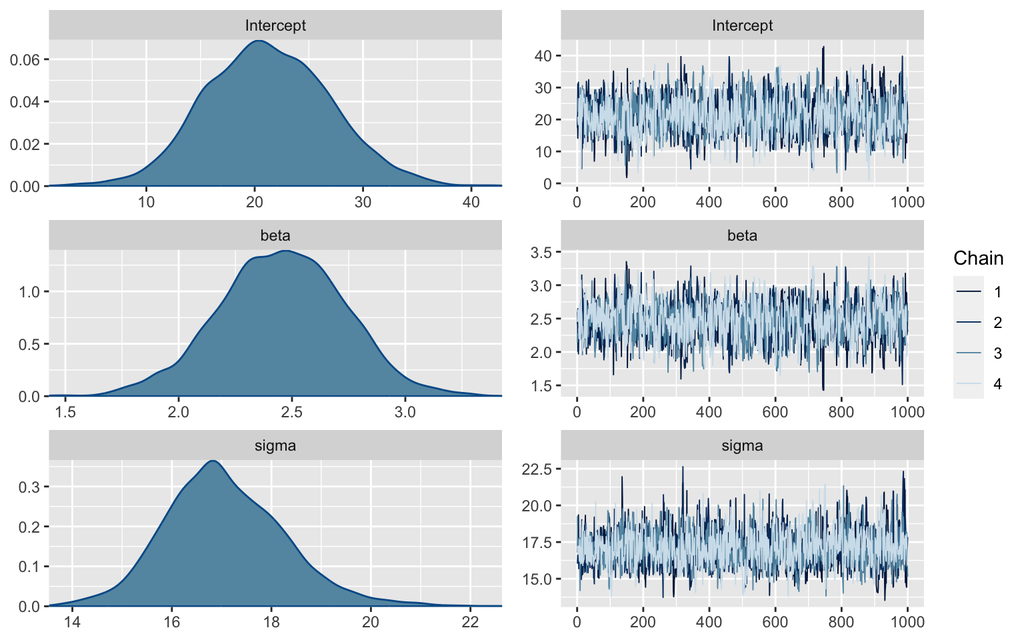

- 収束に問題はない
- 気温の係数がおよそ2.5となっているので，気温が1度上がるごとに，ビールの売り上げは2.5万円前後増えることが予想される

## 2.8 まとめ

- 単回帰モデルでのベイズ推定の流れ

1. Rパッケージの読み込みなどの，分析の準備を行う  
2. データを読み込み，その特徴をグラフなどで確認する  
3. Stanファイルを実装する  
4. MCMを実行する  
5. 収束していることを確認する  
6. 興味のあるパラメータなどの事後分布を確認して，結果の解釈などに活用する

# 第3章 モデルを用いた予測

- [R script](https://github.com/logics-of-blue/book-r-stan-bayesian-model-intro/blob/master/book-data/3-3-%E3%83%A2%E3%83%87%E3%83%AB%E3%82%92%E7%94%A8%E3%81%84%E3%81%9F%E4%BA%88%E6%B8%AC.R)

## 3.1 本章の目的と概要

- 単回帰モデルを用いて予測を行う
- ベイス信用区間と予測区間
  - ベイズ信用区間：推定されたパラメータの幅（平均値μの事後分布の95%信用区間は0.5~13.2）
  - 予測区間：パラメータの幅を加味した，従属変数yの予測の幅 (気温20度の時の売り上げは15~40と予測される)

## 3.2 分析の準備

- パッケージの読み込みから，データの読み込みまでを行う
  - [第3部2章と同じデータ](https://github.com/logics-of-blue/book-r-stan-bayesian-model-intro/blob/master/book-data/3-2-1-beer-sales-2.csv)を使う

```r
# パッケージの読み込み
library(rstan)
library(bayesplot)

# 計算の高速化
rstan_options(auto_write = TRUE)
options(mc.cores = parallel::detectCores())

# 分析対象のデータ
file_beer_sales_2 <- read.csv("3-2-1-beer-sales-2.csv")

# サンプルサイズ
sample_size <- nrow(file_beer_sales_2)
```

## 3.3 単回帰モデルにおける予測の考え方

- 第2部5章の事後予測チェックと同様に進める
- モデルの構造：$sales_i \sim Normal(Interceot + beta * temperature_i, sigma^2)$
- モデルの推定結果
  - Intercept = 21, beta = 2.5, sigma = 17
- 気温が30度の時の売り上げ
  - $21 + 2.5 * 30 = 96$
- 実際には「Intercept = 21」ではなく，パラメータの事後分布に従うMCMCサンプルが得られているのみ
  - 例：‘Intercept’, ‘beta’, ‘sigma’ のMCMCサンプルが4000個ある
- 気温が30度の時の売り上げの予測分布を得る
  - `mu_pred = Intercept + beta * 30`と`sigma`の MCMCサンプルを得る
    - それぞれ4000個のMCMCサンプルがある
  - `mu_pred`を平均値，`sigma`を標準偏差とする正規分布から乱数 (`sales_pred`)を生成する
    - `sales_pred`も4000個得られる
  - `sales_pred`の分布が予測分布となる

## 3.4 予測のためのデータの整理

- 予測を実行するため，データを整理する
  - 気温が11度から30度まで変化した時，売り上げがどのように変化するかを調べる

```r
# 気温を11度から30度まで変化させて、その時の売り上げを予測する
temperature_pred <-11:30
temperature_pred
```

```
##  [1] 11 12 13 14 15 16 17 18 19 20 21 22 23 24 25 26 27 28 29 30
```

- Stanに渡すデータを`list`形式で用意する

```r
# listにまとめる
data_list_pred <- list(
  N = sample_size,
  sales = file_beer_sales_2$sales,
  temperature = file_beer_sales_2$temperature,
  N_pred = length(temperature_pred),
  temperature_pred = temperature_pred
)
```

## 3.5 予測のためのStanファイルの修正

- [Stanファイルを修正](https://github.com/logics-of-blue/book-r-stan-bayesian-model-intro/blob/master/book-data/3-3-1-simple-lm-pred.stan)する
  - `generated quantities`ブロックを使って予測を行う

```stan
data {
  int N;                  // サンプルサイズ
  vector[N] sales;        // 売り上げデータ
  vector[N] temperature;  // 気温データ

  int N_pred;                        // 予測対象データの大きさ
  vector[N_pred] temperature_pred;   // 予測対象となる気温
}

parameters {
  real Intercept;         // 切片
  real beta;              // 係数
  real<lower=0> sigma;    // 標準偏差
}

model {
  // 平均Intercept + beta*temperature
  // 標準偏差sigmaの正規分布に従ってデータが得られたと仮定
  for (i in 1:N) {
    sales[i] ~ normal(Intercept + beta*temperature[i], sigma);
  }
}

generated quantities {
  vector[N_pred] mu_pred;           // ビールの売り上げの期待値
  vector[N_pred] sales_pred;        // ビールの売り上げの予測値

  for (i in 1:N_pred) {
    mu_pred[i] = Intercept + beta*temperature_pred[i];
    sales_pred[i] = normal_rng(mu_pred[i], sigma);
  }
}
```

- [2章のstanコード](https://github.com/logics-of-blue/book-r-stan-bayesian-model-intro/blob/master/book-data/3-2-2-simple-lm-vec.stan)との違い
  - `data`ブロックで，予測対象となる気温（11〜30度）と，そのデータの大きさ(20)を宣言
- `generated quantities` ブロック
  - `mu_pred`「気温によって変化するビールの売り上げの期待値」と`sales_pred`「平均がmuで，標準偏差がsigmaである正規分布から得られた売り上げ予測値」をMCMCによりサンプリングする
  - `sales_pred`は売り上げデータの持つばらつき`sigma`のため，`mu_pred`よりもさらにばらつきが大きくなる
    - `sales_pred`の95%区間が，95%ベイズ予測区間となる
- i番目の`mu_pred`は，モデルの線形予測子を使って「Intercept + beta*tempearature_pred[i]」と指定するだけで，mu_predのMCMCサンプルが得られる
- `sales_pred`は，「`mu_pred`を平均値とした正規分布から，さらに乱数を生成する」ことによって，MCMCサンプルが得られる
  - `normal_rng(μ，σ)`とすることで，平均μ，標準偏差σの正規分布に従う乱数を生成

## 3.6 MCMCの実行

```r
# MCMCの実行
mcmc_result_pred <- stan(
  file = "3-3-1-simple-lm-pred.stan",
  data = data_list_pred,
  seed = 1
)
```

- 結果の表示
  - 売り上げの期待値`mu_pred`と，売り上げ`sales_pred`も，11度から30度までの20個の予測値が得られる
    - 気温11度の時の予想値は48，30度になると95前後
    - `mu_pred`よりも`sales_pred`のMCMCサンプルの95%区間の幅が広くなっている

```r
# 結果の表示
print(mcmc_result_pred, probs = c(0.025, 0.5, 0.975))
```

```
## Inference for Stan model: 3-3-1-simple-lm-pred.
## 4 chains, each with iter=2000; warmup=1000; thin=1;
## post-warmup draws per chain=1000, total post-warmup draws=4000.
##
##                   mean se_mean    sd    2.5%     50%   97.5% n_eff Rhat
## Intercept        21.05    0.18  6.11    9.12   21.01   32.82  1168    1
## beta              2.47    0.01  0.29    1.90    2.46    3.04  1191    1
## sigma            17.11    0.03  1.27   14.89   17.02   19.97  1847    1
## mu_pred[1]       48.17    0.09  3.14   42.06   48.17   54.20  1336    1
## mu_pred[2]       50.64    0.08  2.90   44.97   50.63   56.22  1397    1
## mu_pred[3]       53.11    0.07  2.67   47.80   53.09   58.29  1483    1
## mu_pred[4]       55.57    0.06  2.45   50.78   55.56   60.38  1612    1
## mu_pred[5]       58.04    0.05  2.26   53.63   58.04   62.43  1802    1
## mu_pred[6]       60.50    0.05  2.08   56.37   60.50   64.54  2097    1
## mu_pred[7]       62.97    0.04  1.93   59.15   62.96   66.74  2523    1
## mu_pred[8]       65.44    0.03  1.82   61.83   65.47   69.00  3140    1
## mu_pred[9]       67.90    0.03  1.75   64.40   67.94   71.38  4019    1
## mu_pred[10]      70.37    0.03  1.73   66.89   70.39   73.70  4649    1
## mu_pred[11]      72.84    0.03  1.76   69.30   72.85   76.17  4732    1
## mu_pred[12]      75.30    0.03  1.84   71.61   75.31   78.83  4481    1
## mu_pred[13]      77.77    0.03  1.96   73.84   77.76   81.59  3694    1
## mu_pred[14]      80.23    0.04  2.11   75.95   80.25   84.33  3066    1
## mu_pred[15]      82.70    0.04  2.29   78.04   82.72   87.17  2615    1
## mu_pred[16]      85.17    0.05  2.50   80.05   85.18   89.96  2301    1
## mu_pred[17]      87.63    0.06  2.72   82.13   87.64   92.83  2082    1
## mu_pred[18]      90.10    0.07  2.95   84.18   90.10   95.70  1924    1
## mu_pred[19]      92.56    0.08  3.19   86.19   92.60   98.71  1808    1
## mu_pred[20]      95.03    0.08  3.44   88.11   95.07  101.63  1720    1
## sales_pred[1]    48.17    0.27 17.28   14.73   48.01   82.33  4009    1
## sales_pred[2]    50.86    0.28 17.51   17.39   50.46   87.05  3941    1
## sales_pred[3]    53.25    0.31 17.59   19.75   53.43   87.76  3258    1
## sales_pred[4]    55.82    0.29 17.79   22.18   55.94   91.38  3857    1
## sales_pred[5]    57.83    0.27 17.00   24.51   57.74   90.95  4105    1
## sales_pred[6]    60.80    0.28 17.03   26.92   60.88   94.36  3775    1
## sales_pred[7]    63.01    0.27 17.13   29.10   63.04   97.46  3967    1
## sales_pred[8]    65.56    0.28 17.44   30.79   65.57   98.95  3840    1
## sales_pred[9]    68.12    0.27 17.34   34.40   68.14  102.16  4242    1
## sales_pred[10]   70.65    0.28 17.21   37.04   70.50  104.87  3752    1
## sales_pred[11]   73.21    0.28 17.19   39.63   73.35  107.14  3757    1
## sales_pred[12]   75.15    0.27 16.91   41.78   75.16  108.63  3963    1
## sales_pred[13]   78.13    0.28 17.35   43.77   78.30  111.48  3861    1
## sales_pred[14]   80.18    0.27 17.49   45.63   80.37  114.56  4278    1
## sales_pred[15]   82.39    0.28 17.33   49.37   82.35  116.90  3905    1
## sales_pred[16]   85.04    0.27 17.24   50.82   84.84  119.02  4012    1
## sales_pred[17]   88.14    0.28 17.46   54.25   88.06  121.90  3851    1
## sales_pred[18]   90.10    0.27 17.54   55.74   90.16  124.40  4112    1
## sales_pred[19]   92.85    0.28 17.25   59.08   92.68  126.85  3780    1
## sales_pred[20]   95.07    0.28 17.22   61.68   95.14  129.24  3922    1
## lp__           -330.21    0.04  1.32 -333.72 -329.86 -328.73  1193    1
##
## Samples were drawn using NUTS(diag_e) at Fri Mar 31 12:35:39 2023.
## For each parameter, n_eff is a crude measure of effective sample size,
## and Rhat is the potential scale reduction factor on split chains (at
## convergence, Rhat=1).
```

## 3.7 予測分布の可視化

- 予測結果を図示する
  - MCMCサンプルを抽出してから，`bayesplot`パッケージを使って関数を図示する
- `extract`関数でMCMCサンプルを抽出する

```r
# MCMCサンプルの抽出
mcmc_sample_pred <- rstan::extract(mcmc_result_pred,
                                   permuted = FALSE)
```

- 気温を11〜30度に変化させた時の95%ベイズ予測区間を，`mcmc_interval`関数を使って図示する
  - `sales_pred`の95%区間
  - 引数に`regex_pars`を使うことで，**正規表現**を使うことができる
    - 本来なら`sales_pred[1]`といった添字をつけて指定する必要があったのが，正規表現を使うことで，短いコードで実装できる
    - [正規表現（regular expressions, regex）](https://opur.club/textbook/2018-5-2/)：文字のパターン」に対して処理を行うための規則

```r
# 気温が11度～30度まで1度ずつ変えたの時の
# 予測売り上げの95%予測区間の図示
mcmc_intervals(
  mcmc_sample_pred,
  regex_pars = c("sales_pred."), # 正規表現を用いてパラメタ名を指定
  prob = 0.8,        # 太い線の範囲
  prob_outer = 0.95  # 細い線の範囲
)
```

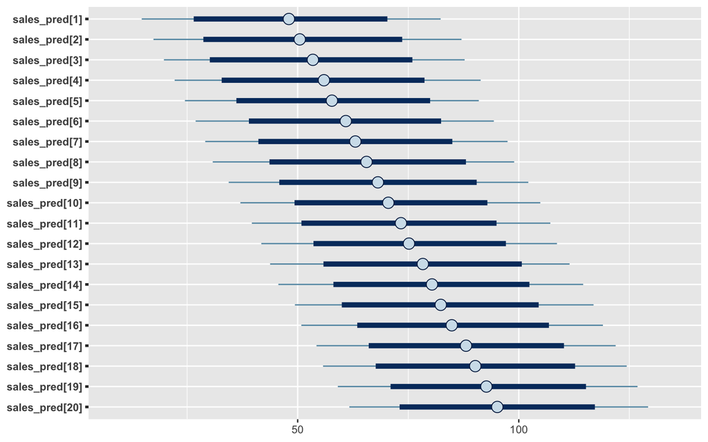

- `mu_pred`と`sales_pred`の95%区間を比較
  - 予測区間は，データの持つばらつきのため，平均値の信用区間よりも広くなる

```r
# 95%区間の比較
mcmc_intervals(
  mcmc_sample_pred,
  pars = c("mu_pred[1]", "sales_pred[1]"),
  prob = 0.8,        # 太い線の範囲
  prob_outer = 0.95  # 細い線の範囲
)
```

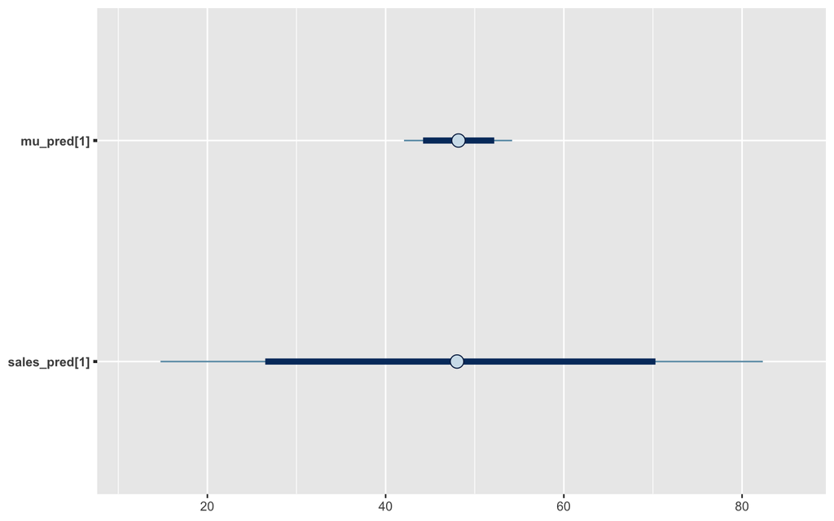

- 予測分布の図示
  - 11度と30度の時の売り上げ予測を比較

```r
# 気温が11度と30度の時の、売り上げの予測分布
mcmc_areas(
  mcmc_sample_pred,
  pars = c("sales_pred[1]", "sales_pred[20]"),
  prob = 0.6,        # 薄い青色で塗られた範囲
  prob_outer = 0.99  # 細い線が描画される範囲
)
```

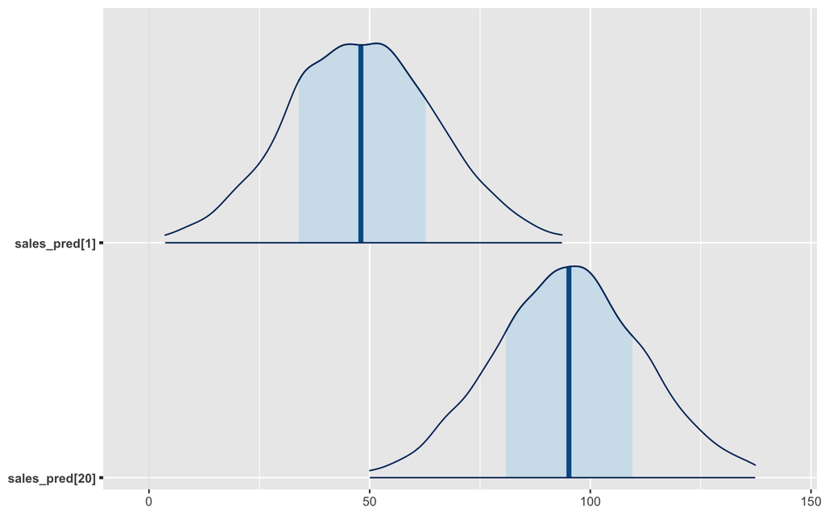

# 第4章 デザイン行列を用いた一般化線形モデルの推定

- R script

## 4.1 本章の目的と概要

- デザイン行列を用いて一般化線形モデルを表現した上で，Stanによる推定を試みる
- 次章から用いるbrmsは`formula`構文に対応しており，簡潔にモデルを実装できる
  - brmsは簡潔すぎて内部の構造が理解しにくいため，`formula`構文と一般化線形モデルの構造との対応づけができるようにする

## 4.2 分析の準備

- パッケージの読み込みから，データの読み込みまでを行う
  - [第3部2章と同じデータ](https://github.com/logics-of-blue/book-r-stan-bayesian-model-intro/blob/master/book-data/3-2-1-beer-sales-2.csv)を使う

```r
# 分析の準備 -------------------------------------------------------------------

# パッケージの読み込み
library(rstan)
library(bayesplot)

# 計算の高速化
rstan_options(auto_write = TRUE)
options(mc.cores = parallel::detectCores())

# 分析対象のデータ
file_beer_sales_2 <- read.csv("3-2-1-beer-sales-2.csv")

# サンプルサイズ
sample_size <- nrow(file_beer_sales_2)
```

## デザイン行列を使ったモデルの数学的な表現

$$\boldsymbol{\beta}
= \begin{bmatrix}
\beta_0 \\ \beta_1
\end{bmatrix}$$

- 応答変数の期待値のベクトルを$\boldsymbol{\mu}$, 係数のベクトルを$\boldsymbol{\beta}$, デザイン行列を$\boldsymbol{X}$とすると，以下の関係が成り立つ

- デザイン行列を使うと，スカラー表記よりも簡潔にモデルを表現できる
- モデルの構造が多少変わっても（例：説明変数の数が増える），デザイン行列を変更するだけで対応が可能
- Stanファイルをいちいち書き換えなくて済むというメリットがある

## 4.4 formula構文を用いたデザイン行列の作成

- デザイン行列$\boldsymbol{X}$は，`formula`という記法を用いて作成
  - `formula`では`~`の左側に応答変数，右側に説明変数を配置する
  - 作成された`formula`と，元となる`data.frame`を引数に`model.matrix`という関数を使うことでデザイン行列が得られる

```r
# formula構文を用いたデザイン行列の作成 --------------------------------------------------------

# formulaの作成
formula_lm <- formula(sales ~ temperature)

# デザイン行列の作成
X <- model.matrix(formula_lm, file_beer_sales_2)

# formulaとmodel.matrixを使ったデザイン行列
head(X, n = 5)
```

```
##   (Intercept) temperature
## 1           1        13.7
## 2           1        24.0
## 3           1        21.5
## 4           1        13.4
## 5           1        28.9
```

## 4.5 デザイン行列を使うためのStanファイルの修正

```stan
data {
  int N;                // サンプルサイズ
  int K;                // デザイン行列の列数(説明変数の数＋１)
  vector[N] Y;          // 応答変数
  matrix[N, K] X;       // デザイン行列
}

parameters {
  vector[K] b;          // 切片を含む係数ベクトル
  real<lower=0> sigma;  // データのばらつきを表す標準偏差
}

model {
  vector[N] mu = X * b;
  Y ~ normal(mu, sigma);
}
```

## 4.6 MCMCの実行

- デザイン行列などを`list`にまとめてから，MCMCを実行する

```r
# MCMCの実行 -----------------------------------------------------------------

# サンプルサイズ
N <- nrow(file_beer_sales_2)

# デザイン行列の列数（説明変数の数＋１）
K <- 2

# 応答変数
Y <- file_beer_sales_2$sales

# listにまとめる
data_list_design <- list(N = N, K = K, Y = Y, X = X)

# MCMCの実行
mcmc_result_design <- stan(
  file = "3-4-1-lm-design-matrix.stan",
  data = data_list_design,
  seed = 1
)
```

- 結果
  - `b[1]`が切片，`b[2]`が傾き
  - デザイン行列を変えるだけで様々なモデルに対応できるので，Stanファイルを書き換える必要がなくなる

```r
# 結果の表示
print(mcmc_result_design,  probs = c(0.025, 0.5, 0.975))
```

```
## Inference for Stan model: 3-4-1-lm-design-matrix.
## 4 chains, each with iter=2000; warmup=1000; thin=1;
## post-warmup draws per chain=1000, total post-warmup draws=4000.
##
##          mean se_mean   sd    2.5%     50%   97.5% n_eff Rhat
## b[1]    20.78    0.17 5.89    9.31   20.74   32.27  1247    1
## b[2]     2.48    0.01 0.29    1.91    2.47    3.04  1245    1
## sigma   17.06    0.03 1.25   14.89   16.97   19.67  1514    1
## lp__  -330.17    0.04 1.26 -333.43 -329.85 -328.74  1154    1
##
## Samples were drawn using NUTS(diag_e) at Fri Mar 31 12:35:42 2023.
## For each parameter, n_eff is a crude measure of effective sample size,
## and Rhat is the potential scale reduction factor on split chains (at
## convergence, Rhat=1).
```

# 5章 brmsの使い方

- [Rcode](https://github.com/logics-of-blue/book-r-stan-bayesian-model-intro/blob/master/book-data/3-5-brms%E3%81%AE%E4%BD%BF%E3%81%84%E6%96%B9.R)

## 5.1 本章の目的

- brmsという，一般化線形モデルなどを簡単に推定できるパッケージの使い方の解説
  - 本書ではver 2.8.0, 2.9.0を使って解説（最新版は2.19.0）
- brmsを使うことで，ベイズ統計モデリングを行うハードルを下げる
  - brms の結果をStanで再現する，事前分布の設定を変更するなど，やや応用的な面も扱う

## 5.2 brmsとは

- Bayesian Regression Models using ’Stan’の略
- 一般化線形モデルなどの回帰モデルをStanを使って推定するパッケージ
  - Stanコードを書く必要がないので，簡単に実装できる
  - 一般化線形混合モデルなど，応用的なモデルも推定できる
- brmsのように簡単にベイズ統計モデリングを行えるパッケージとして`rstanarm`などがある

## 5.3 本書での実装の方針

- 単純なモデルである場合は積極的にbrmsを使用し，分析にかけるコストを下げる
  - 内部の構造がブラックボックスとなっていまうこともあるので，補足としてStanファイルの書き方をあわせて示す場合もある

## 5.4 分析の準備

- データは3.2で使ったビールの売り上げデータ 3-2-1-beer-sales-2.csv

```r
# パッケージの読み込み
library(rstan)
library(brms)

# 計算の高速化
rstan_options(auto_write = TRUE)
options(mc.cores = parallel::detectCores())

# 分析対象のデータ
file_beer_sales_2 <- read.csv("3-2-1-beer-sales-2.csv")
```

## 5.5 brmsによる単回帰モデルの推定

- `brm`関数を使って，単回帰モデルを推定する
- 一般化線形モデルでは，線形予測子・確率分布・リンク関数の3つを指定することでモデルの構造を決める
  - この3点を指定すれば，Stanコードの自動生成が可能
- 線形予測子は`formula`, 確率分布とリンク関数は`family`という引数で指定

```r
# 単回帰モデルを作る
simple_lm_brms <- brm(
  formula = sales ~ temperature,         # modelの構造を指定
  family = gaussian(link = "identity"),  # 正規分布を使う
  data = file_beer_sales_2,              # データ
  seed = 1                               # 乱数の種
)
```

```
## Trying to compile a simple C file
```

### 推定結果

- `Intercept`が切片，`temperature`が気温の係数, `Estimate`が事後期待値

```r
# MCMCの結果の確認
simple_lm_brms
```

```
##  Family: gaussian
##   Links: mu = identity; sigma = identity
## Formula: sales ~ temperature
##    Data: file_beer_sales_2 (Number of observations: 100)
##   Draws: 4 chains, each with iter = 2000; warmup = 1000; thin = 1;
##          total post-warmup draws = 4000
##
## Population-Level Effects:
##             Estimate Est.Error l-95% CI u-95% CI Rhat Bulk_ESS Tail_ESS
## Intercept      21.03      5.91     9.37    32.13 1.00     3686     2710
## temperature     2.46      0.29     1.92     3.05 1.00     3750     2653
##
## Family Specific Parameters:
##       Estimate Est.Error l-95% CI u-95% CI Rhat Bulk_ESS Tail_ESS
## sigma    16.99      1.20    14.83    19.51 1.00     3801     3110
##
## Draws were sampled using sampling(NUTS). For each parameter, Bulk_ESS
## and Tail_ESS are effective sample size measures, and Rhat is the potential
## scale reduction factor on split chains (at convergence, Rhat = 1).
```

- `as.mcmc`関数を用いることでMCMCサンプルを取得できる
  - `coda`パッケージで利用しやすい
  - MCMCサンプルを使うことで，事後分布のグラフや予測値の計算などが行える

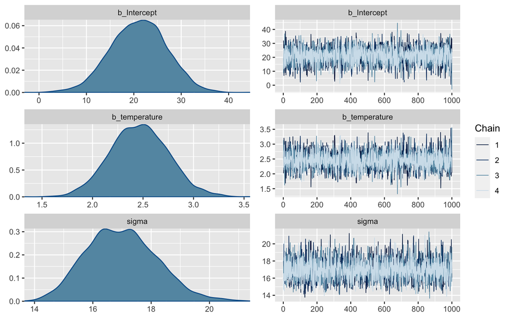

```r
# 参考：MCMCサンプルの取得
## as.mcmc(simple_lm_brms, combine_chains = TRUE)

# 事後分布の図示
plot(simple_lm_brms)
```

## 5.6 brmsの基本的な使い方

- 線形予測子は`formula`, 確率分布とリンク関数は`famly`という引数で指定する
- `formula`は`brm`関数の中で直接指定できるが，複雑なモデルの場合`bf`関数で外出しして作成する

```
# 複雑なformulaはbf関数で作成
simple_lm_formula <- bf(sales~temperature)
```

```
# familyは様々選べる。
# デフォルトのリンク関数は省略可能
# 正規分布
gaussian()
# 二項分布
binomial()
# ポアソン分布
poisson()
```

- MCMCを実行する際は`brm`関数を使う
  - 引数を追加することで，チェーン数や，繰り返し数，バーンイン期間，間引き数などを指定できる
  - 指定しない場合は，標準の設定が使われる

```
# 標準で指定されているチェーン数を明示的に指示したコード

# simple_lm_brmsと結果は同じ

simple_lm_brms_2 <- brm(
  formula = simple_lm_formula, # bf関数で作成済みのformulaを指定
  family = gaussian(),      # 正規分布を使う(リンク関数省略)
  data = file_beer_sales_2, # データ
  seed = 1,                 # 乱数の種
  chains = 4,               # チェーン数
  iter = 2000,              # 乱数生成の繰り返し数
  warmup = 1000,            # バーンイン期間
  thin = 1                  # 間引き数(1なら間引き無し)
)

# 参考
simple_lm_brms_2
```

## 5.7 事前分布の変更

- brmsではあらかじめ，弱情報事前分布が指定されている
  - どのような事前分布が指定されているかは，`prior_summary`関数で分かる

```r
# 事前分布の取得
prior_summary(simple_lm_brms)
```

```
##                   prior     class        coef group resp dpar nlpar lb ub
##                  (flat)         b
##                  (flat)         b temperature
##  student_t(3, 71.5, 20) Intercept
##     student_t(3, 0, 20)     sigma                                    0
##        source
##       default
##  (vectorized)
##       default
##       default
```

- `prior`の列が事前分布の一覧を表す
  - `student_t(nu, mu, sigma)`という設定で，自由度nu, 分布の中心位置mu, 分布の裾の広さsigmaを指定する
- `class`の列は，パラメータの役割を示した例。`b`ならば係数
  - `coef`列を見ると，どの説明変数にかかる係数か分かる
  - `Intercept`列は切片，`sigma`はデータのばらつきの大きさ
- 幅の広い一様分布を無情報事前分布として使いたい場合は，以下のように指定してMCMCを実行する

```r
# 事前分布を無情報事前分布にする
simple_lm_brms_3 <- brm(
  formula = sales ~ temperature,
  family = gaussian(),
  data = file_beer_sales_2,
  seed = 1,
  prior = c(set_prior("", class = "Intercept"),
            set_prior("", class = "sigma"))
)
```

```
## Trying to compile a simple C file
```

```r
# 参考：推定結果
simple_lm_brms_3
```

```
##  Family: gaussian
##   Links: mu = identity; sigma = identity
## Formula: sales ~ temperature
##    Data: file_beer_sales_2 (Number of observations: 100)
##   Draws: 4 chains, each with iter = 2000; warmup = 1000; thin = 1;
##          total post-warmup draws = 4000
##
## Population-Level Effects:
##             Estimate Est.Error l-95% CI u-95% CI Rhat Bulk_ESS Tail_ESS
## Intercept      21.23      5.99     9.31    32.93 1.00     3928     3023
## temperature     2.46      0.29     1.90     3.02 1.00     3934     3090
##
## Family Specific Parameters:
##       Estimate Est.Error l-95% CI u-95% CI Rhat Bulk_ESS Tail_ESS
## sigma    17.07      1.23    14.79    19.77 1.00     3829     2854
##
## Draws were sampled using sampling(NUTS). For each parameter, Bulk_ESS
## and Tail_ESS are effective sample size measures, and Rhat is the potential
## scale reduction factor on split chains (at convergence, Rhat = 1).
```

```r
# 参考：弱情報事前分布が設定されなくなった
prior_summary(simple_lm_brms_3)
```

```
##   prior     class        coef group resp dpar nlpar lb ub       source
##  (flat)         b                                              default
##  (flat)         b temperature                             (vectorized)
##  (flat) Intercept                                                 user
##  (flat)     sigma                                    0            user
```

```
# 参考：stanコードの抽出
stancode(simple_lm_brms_3)

# 参考：Stanに渡すデータの抽出
standata(simple_lm_brms_3)
```

## 5.8 補足:brmsの基本的な仕組み

- [Bürkner](https://www.jstatsoft.org/article/view/v080i01)
- `brm`関数に「モデルを構築するのに必要な情報」を全て渡す
  - 線形予測子，確率分布，リンク関数，データ，MCMC実行の際のオプション
- brmsは内部でStanを利用している
  - `make_stancode`関数を使って，Stanファイルに実装するコードを生成
  - `make_standata`関数を使ってデータを作成
  - brmsから呼び出されたStanがMCMCを実行
  - MCMCの実行結果をbrms側が受け取り，出力

## 5.9 補足：`make_stancode`関数による，Stanコードの作成

- brmsを介さずに，Stanファイルに直接コードを書いてもStanと同じ結果が出せる
  - 本節では`simple_lm_brms_3`の再現を試みる
- `make_stancode`関数を使い，Stanコードを作成する
  - 引数にはモデルの構造を指定するのに必要な情報を指定
  - 線形予測子 `formula`，確率分布とリンク関数 `family`，データ `data`，事前分布 `prior`

```r
# 補足：make_stancode関数による、Stanコードの作成 ------------------------------------

# Stanコードを作る
make_stancode(
  formula = sales ~ temperature,
  family = gaussian(),
  data = file_beer_sales_2,
  prior = c(prior("", class = "Intercept"),
            prior("", class = "sigma"))
)
```

```
## // generated with brms 2.19.0
## functions {
## }
## data {
##   int<lower=1> N;  // total number of observations
##   vector[N] Y;  // response variable
##   int<lower=1> K;  // number of population-level effects
##   matrix[N, K] X;  // population-level design matrix
##   int prior_only;  // should the likelihood be ignored?
## }
## transformed data {
##   int Kc = K - 1;
##   matrix[N, Kc] Xc;  // centered version of X without an intercept
##   vector[Kc] means_X;  // column means of X before centering
##   for (i in 2:K) {
##     means_X[i - 1] = mean(X[, i]);
##     Xc[, i - 1] = X[, i] - means_X[i - 1];
##   }
## }
## parameters {
##   vector[Kc] b;  // population-level effects
##   real Intercept;  // temporary intercept for centered predictors
##   real<lower=0> sigma;  // dispersion parameter
## }
## transformed parameters {
##   real lprior = 0;  // prior contributions to the log posterior
## }
## model {
##   // likelihood including constants
##   if (!prior_only) {
##     target += normal_id_glm_lpdf(Y | Xc, Intercept, b, sigma);
##   }
##   // priors including constants
##   target += lprior;
## }
## generated quantities {
##   // actual population-level intercept
##   real b_Intercept = Intercept - dot_product(means_X, b);
## }
```

## 5.10 補足：`make_standata`関数による，Stanに渡すデータの作成

- Stanに渡すデータを`make_standata`関数で作成する

```r
# 補足：make_standata関数による、Stanに渡すデータの作成 ------------------------------------

# rstanに渡すデータを作る
standata_brms <- make_standata(
  formula = sales ~ temperature,
  family = gaussian(),
  data = file_beer_sales_2
)

lapply(standata_brms, function(x) head(x, min(5, length(x))))
```

```
## $N
## [1] 100
##
## $Y
## [1]  41.68 110.99  65.32  72.64  76.54
##
## $K
## [1] 2
##
## $X
##   Intercept temperature
## 1         1        13.7
## 2         1        24.0
## 3         1        21.5
## 4         1        13.4
## 5         1        28.9
##
## $prior_only
## [1] 0
```

- Yが応答変数，Xがデザイン行列, Xの2列目が説明変数

## 5.11 補足：rstanでbrmsの結果を再現する

- `make_stancode`関数で得られたStanコードと，`make_standata`関数を使って得られたデータを使ってMCMCを実行

```r
# 補足：rstanでbrmsの結果を再現する ---------------------------------------------------

# rstanでbrmsのモデルを実行
simple_lm_brms_stan <- stan(
  file = "3-5-1-brms-stan-code.stan",
  data = standata_brms,
  seed = 1
)
```

- 結果を出力する

```r
# rstanを使ったときの実行結果
print(simple_lm_brms_stan,
      pars = c("b_Intercept", "b[1]", "sigma"),
      probs = c(0.025, 0.5, 0.975))
```

```
## Inference for Stan model: 3-5-1-brms-stan-code.
## 4 chains, each with iter=2000; warmup=1000; thin=1;
## post-warmup draws per chain=1000, total post-warmup draws=4000.
##
##              mean se_mean   sd  2.5%   50% 97.5% n_eff Rhat
## b_Intercept 21.21    0.10 5.92  9.37 21.25 32.95  3460    1
## b[1]         2.45    0.00 0.29  1.89  2.45  3.02  3418    1
## sigma       17.08    0.02 1.24 14.83 17.01 19.72  3117    1
##
## Samples were drawn using NUTS(diag_e) at Fri Mar 31 12:36:27 2023.
## For each parameter, n_eff is a crude measure of effective sample size,
## and Rhat is the potential scale reduction factor on split chains (at
## convergence, Rhat=1).
```

```r
# brmsを使ったときの実行結果
simple_lm_brms_3
```

```
##  Family: gaussian
##   Links: mu = identity; sigma = identity
## Formula: sales ~ temperature
##    Data: file_beer_sales_2 (Number of observations: 100)
##   Draws: 4 chains, each with iter = 2000; warmup = 1000; thin = 1;
##          total post-warmup draws = 4000
##
## Population-Level Effects:
##             Estimate Est.Error l-95% CI u-95% CI Rhat Bulk_ESS Tail_ESS
## Intercept      21.23      5.99     9.31    32.93 1.00     3928     3023
## temperature     2.46      0.29     1.90     3.02 1.00     3934     3090
##
## Family Specific Parameters:
##       Estimate Est.Error l-95% CI u-95% CI Rhat Bulk_ESS Tail_ESS
## sigma    17.07      1.23    14.79    19.77 1.00     3829     2854
##
## Draws were sampled using sampling(NUTS). For each parameter, Bulk_ESS
## and Tail_ESS are effective sample size measures, and Rhat is the potential
## scale reduction factor on split chains (at convergence, Rhat = 1).
```

## 5.12 brmsによる事後分布の可視化

- `plot(simple_lm_brms)`で事後分布とトレースプロットが得られる
- 95%信用区間を描画
  - `type`でグラフの種類，`pars`で描画対象のパラメータを指定
  - `stanplot`, `pars`は現在は推奨されておらず，`mcmc_plot`, `variable`を使うのが望ましい

```r
# 係数の95%ベイズ信用区間
stanplot(simple_lm_brms,
         type = "intervals",
         pars = "^b_",
         prob = 0.8,        # 太い線の範囲
         prob_outer = 0.95) # 細い線の範囲
```

[figure not shown]

### 補足

- [`easystats`](https://easystats.github.io/easystats/)パッケージの，[`bayestestR`](https://easystats.github.io/bayestestR/),[`see`](https://easystats.github.io/see/articles/bayestestR.html)を使うと，簡単に描画できる

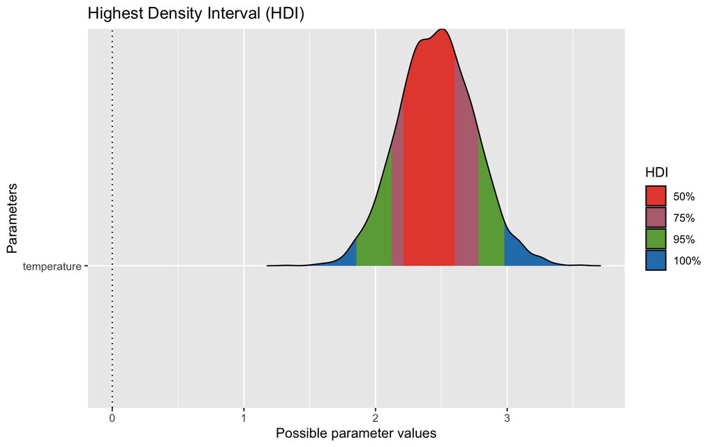

```r
library(easystats)
plot(hdi(simple_lm_brms, ci = c(0.5, 0.75, 0.95)))
```

## 5.13 brmsによる予測

- brmsを使うことで，モデルの当てはめ値の取得や，特定の気温の時の売り上げを予測できる
- 20度の時の売り上げを予測する
- 20度の気温をデータフレームに格納する

```r
# 予測のための説明変数
new_data <- data.frame(temperature = 20)
```

- `fitted`関数を使い，モデルの予測値を回帰直線の95%ベイズ信用区間と合わせて出力する
  - Estimateは事後平均値をもとにして計算される

```r
# 回帰直線の信用区間付きの予測値
fitted(simple_lm_brms, new_data)
```

```
##      Estimate Est.Error     Q2.5    Q97.5
## [1,] 70.31671  1.688772 67.01434 73.65653
```

- `predict`関数を使うことで，モデルの予測値を95%ベイズ予測区間と合わせて出力できる

```r
# 予測区間付きの予測値
set.seed(1)
predict(simple_lm_brms, new_data)
```

```
##      Estimate Est.Error     Q2.5  Q97.5
## [1,] 70.31382  17.68644 34.87692 104.36
```

- Q2.5~Q97.5の幅は`fitted`よりも`predict`の方が広い
- 予測区間を出す時は，`rnorm`関数で正規乱数を発生させており，実行するたびに微妙に予測区間が変わるため，乱数の種をset.seed(1)として指定

## 5.14 補足:predict関数を使わない予測の実装

```r
# 補足：predict関数を使わない予測の実装 ----------------------------------------------------------------

# MCMCサンプルを取り出す
mcmc_sample <- as.mcmc(simple_lm_brms, combine_chains = TRUE)
head(mcmc_sample, n = 2)
```

[output not shown]

- 計算しやすくするため，各のパラメータのMCMCサンプルを個別に取り出す

```r
# 推定されたパラメタ別に保存しておく
mcmc_b_Intercept   <- mcmc_sample[,"b_Intercept"]
mcmc_b_temperature <- mcmc_sample[,"b_temperature"]
mcmc_sigma         <- mcmc_sample[,"sigma"]
```

- 気温が20度の時の売り上げの予測値は$切片+20 * 傾き$で得られる
  - この予測値の結果もMCMCサンプルの個数 (4000) ある

```r
# 予測された期待値のMCMCサンプルを得る
saigen_fitted <- mcmc_b_Intercept + 20 * mcmc_b_temperature
```

- `saigen_fitted`の結果の要約統計量は，`fitted`関数の結果に一致する

```r
# fittedの再現
mean(saigen_fitted)
```

```
## [1] 70.31671
```

```r
quantile(saigen_fitted, probs = c(0.025, 0.975))
```

```
##     2.5%    97.5%
## 67.01434 73.65653
```

```r
fitted(simple_lm_brms, new_data)
```

```
##      Estimate Est.Error     Q2.5    Q97.5
## [1,] 70.31671  1.688772 67.01434 73.65653
```

- 予測区間を得る場合は，モデルの`sigma`で表現されたデータのばらつきも上する必要がある
- 平均値が`saigen_effect`, SDが`mcmc_sigma`である正規乱数を生成
  - `da.call`関数は繰り返し計算をする関数で，引数に入れた`rnorm`関数を4000回繰り返して実行
- `saigen_predict`の結果の要約統計量は，`predict`関数の結果に一致

```r
# 予測分布のMCMCサンプルを得る
set.seed(1)
saigen_predict <- do.call(
  rnorm,
  c(4000, list(mean = saigen_fitted, sd = mcmc_sigma))
)

# predictの再現
mean(saigen_predict)
```

```
## [1] 70.31382
```

```r
quantile(saigen_predict, probs = c(0.025, 0.975))
```

```
##      2.5%     97.5%
##  34.87692 104.36003
```

```r
set.seed(1)
predict(simple_lm_brms, data.frame(temperature = 20))
```

```
##      Estimate Est.Error     Q2.5  Q97.5
## [1,] 70.31382  17.68644 34.87692 104.36
```

- `saigen_fitted`を平均値とする正規分布から乱数を得て，`saigen_predict`を得る
  - 第3部3章の`generated quantities`を使った方法と似ている

## 5.15 回帰直線の図示

- brmsの推定結果をもとに，*回帰直線*で気温の変化とビールの売り上げの平均値の関係を可視化する
- 95%ベイズ信用区間付きの回帰直線を, `marginal_effect`関数を使って描画

```r
# 回帰直線の95%ベイズ信用区間付きのグラフ
eff <- marginal_effects(simple_lm_brms)
```

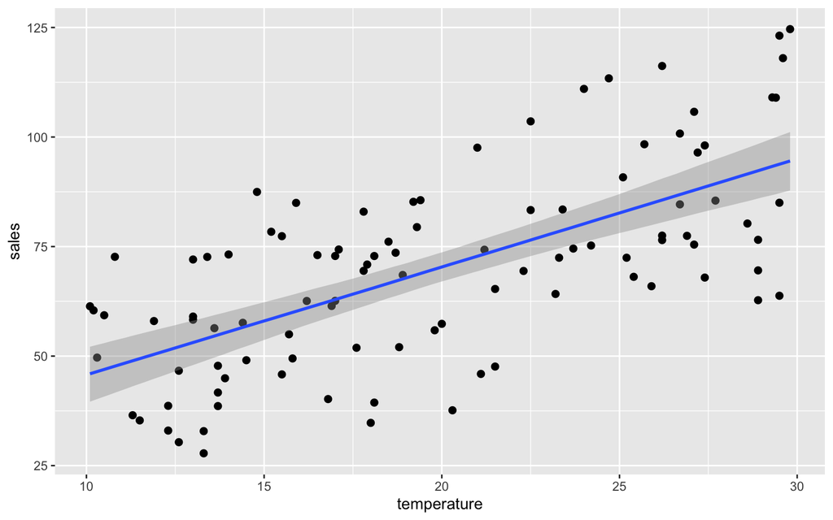

```r
plot(eff, points = TRUE)
```

- 95%予測区間付きの回帰直線は，`method="predict"`を追加して描画

```r
# 95%予測区間付きのグラフ
set.seed(1)
eff_pre <- marginal_effects(simple_lm_brms, method = "predict")
```

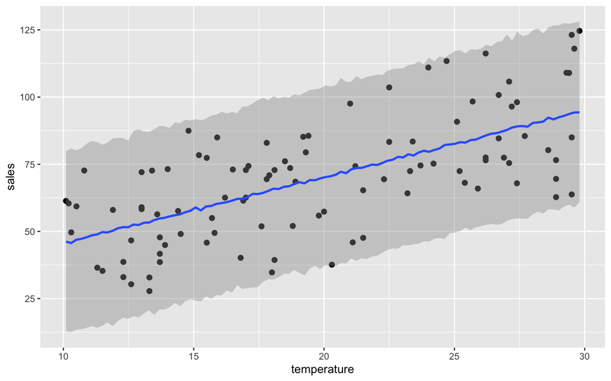

```r
plot(eff_pre, points = TRUE)
```

- 推定されたモデルから得られた予測分布と実際のデータの比較は，モデルの評価をする際に有効
  - 95%予測区間からデータが多くはみ出している場合，モデルの構造を修正した方が良い

### 補足

- 説明変数が多いと描画が困難になるため，`effect`引数を使い，特定の説明変数にフォーカスしてグラフを描画することも可能

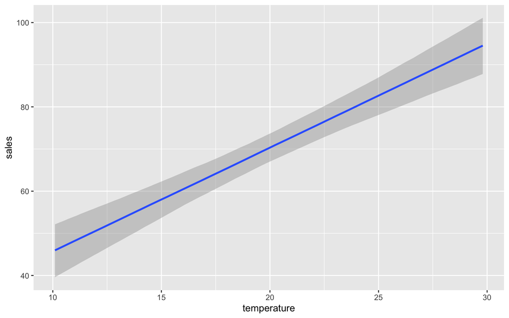

```r
# 参考：複数の説明変数があるときは、特定の要因だけを切り出せる
marginal_effects(simple_lm_brms,
                 effects = "temperature")
```